# Part I - (Dataset Exploration Ford GoBike System Data)

## Introduction

> This data set includes information about individual rides made in a bike-sharing system covering the greater San Francisco Bay area. The dataset has 16 columns and 183412 rows. This presentation aims at looking at the main aspects of bike-sharing in the larger San Francisco Bay area. The major purpose here is to identify the key determinants of trip duration by examining the relationship between trip duration and other explanatory variables in the dataset. We attempt to answer the following questions. How does journey duration fluctuate depending on user age, hour, day, and user type? What does the journey duration distribution look like? Which days are the busiest for trips? Which times of day are the most popular for trips?

## Preliminary Wrangling

```python
# import all packages and set plots to be embedded inline
import numpy as np
import pandas as pd
import matplotlib.pyplot as plt
import seaborn as sb

%matplotlib inline
```

> The dataset was provided by Udacity and I downloaded it manually

```python
data=pd.read_csv('201902-fordgobike-tripdata.csv')
data.head()
```

|  | duration_sec | start_time | end_time | start_station_id | start_station_name | start_station_latitude | start_station_longitude | end_station_id | end_station_name | end_station_latitude | end_station_longitude | bike_id | user_type | member_birth_year | member_gender | bike_share_for_all_trip |
| --- | --- | --- | --- | --- | --- | --- | --- | --- | --- | --- | --- | --- | --- | --- | --- | --- |
| 0 | 52185 | 2019-02-28 17:32:10.1450 | 2019-03-01 08:01:55.9750 | 21.0 | Montgomery St BART Station (Market St at 2nd St) | 37.789625 | -122.400811 | 13.0 | Commercial St at Montgomery St | 37.794231 | -122.402923 | 4902 | Customer | 1984.0 | Male | No |
| 1 | 42521 | 2019-02-28 18:53:21.7890 | 2019-03-01 06:42:03.0560 | 23.0 | The Embarcadero at Steuart St | 37.791464 | -122.391034 | 81.0 | Berry St at 4th St | 37.775880 | -122.393170 | 2535 | Customer | NaN | NaN | No |
| 2 | 61854 | 2019-02-28 12:13:13.2180 | 2019-03-01 05:24:08.1460 | 86.0 | Market St at Dolores St | 37.769305 | -122.426826 | 3.0 | Powell St BART Station (Market St at 4th St) | 37.786375 | -122.404904 | 5905 | Customer | 1972.0 | Male | No |
| 3 | 36490 | 2019-02-28 17:54:26.0100 | 2019-03-01 04:02:36.8420 | 375.0 | Grove St at Masonic Ave | 37.774836 | -122.446546 | 70.0 | Central Ave at Fell St | 37.773311 | -122.444293 | 6638 | Subscriber | 1989.0 | Other | No |
| 4 | 1585 | 2019-02-28 23:54:18.5490 | 2019-03-01 00:20:44.0740 | 7.0 | Frank H Ogawa Plaza | 37.804562 | -122.271738 | 222.0 | 10th Ave at E 15th St | 37.792714 | -122.248780 | 4898 | Subscriber | 1974.0 | Male | Yes |

```python
#Create a copy of the dataset
data_clean = data.copy()
data_clean.head()
```

|  | duration_sec | start_time | end_time | start_station_id | start_station_name | start_station_latitude | start_station_longitude | end_station_id | end_station_name | end_station_latitude | end_station_longitude | bike_id | user_type | member_birth_year | member_gender | bike_share_for_all_trip |
| --- | --- | --- | --- | --- | --- | --- | --- | --- | --- | --- | --- | --- | --- | --- | --- | --- |
| 0 | 52185 | 2019-02-28 17:32:10.1450 | 2019-03-01 08:01:55.9750 | 21.0 | Montgomery St BART Station (Market St at 2nd St) | 37.789625 | -122.400811 | 13.0 | Commercial St at Montgomery St | 37.794231 | -122.402923 | 4902 | Customer | 1984.0 | Male | No |
| 1 | 42521 | 2019-02-28 18:53:21.7890 | 2019-03-01 06:42:03.0560 | 23.0 | The Embarcadero at Steuart St | 37.791464 | -122.391034 | 81.0 | Berry St at 4th St | 37.775880 | -122.393170 | 2535 | Customer | NaN | NaN | No |
| 2 | 61854 | 2019-02-28 12:13:13.2180 | 2019-03-01 05:24:08.1460 | 86.0 | Market St at Dolores St | 37.769305 | -122.426826 | 3.0 | Powell St BART Station (Market St at 4th St) | 37.786375 | -122.404904 | 5905 | Customer | 1972.0 | Male | No |
| 3 | 36490 | 2019-02-28 17:54:26.0100 | 2019-03-01 04:02:36.8420 | 375.0 | Grove St at Masonic Ave | 37.774836 | -122.446546 | 70.0 | Central Ave at Fell St | 37.773311 | -122.444293 | 6638 | Subscriber | 1989.0 | Other | No |
| 4 | 1585 | 2019-02-28 23:54:18.5490 | 2019-03-01 00:20:44.0740 | 7.0 | Frank H Ogawa Plaza | 37.804562 | -122.271738 | 222.0 | 10th Ave at E 15th St | 37.792714 | -122.248780 | 4898 | Subscriber | 1974.0 | Male | Yes |

```python
#obtain the general information about the dataset
data_clean.info()
```

```
<class 'pandas.core.frame.DataFrame'>
RangeIndex: 183412 entries, 0 to 183411
Data columns (total 16 columns):
duration_sec               183412 non-null int64
start_time                 183412 non-null object
end_time                   183412 non-null object
start_station_id           183215 non-null float64
start_station_name         183215 non-null object
start_station_latitude     183412 non-null float64
start_station_longitude    183412 non-null float64
end_station_id             183215 non-null float64
end_station_name           183215 non-null object
end_station_latitude       183412 non-null float64
end_station_longitude      183412 non-null float64
bike_id                    183412 non-null int64
user_type                  183412 non-null object
member_birth_year          175147 non-null float64
member_gender              175147 non-null object
bike_share_for_all_trip    183412 non-null object
dtypes: float64(7), int64(2), object(7)
memory usage: 22.4+ MB
```

```python
data_clean.describe()
```

|  | duration_sec | start_station_id | start_station_latitude | start_station_longitude | end_station_id | end_station_latitude | end_station_longitude | bike_id | member_birth_year |
| --- | --- | --- | --- | --- | --- | --- | --- | --- | --- |
| count | 183412.000000 | 183215.000000 | 183412.000000 | 183412.000000 | 183215.000000 | 183412.000000 | 183412.000000 | 183412.000000 | 175147.000000 |
| mean | 726.078435 | 138.590427 | 37.771223 | -122.352664 | 136.249123 | 37.771427 | -122.352250 | 4472.906375 | 1984.806437 |
| std | 1794.389780 | 111.778864 | 0.099581 | 0.117097 | 111.515131 | 0.099490 | 0.116673 | 1664.383394 | 10.116689 |
| min | 61.000000 | 3.000000 | 37.317298 | -122.453704 | 3.000000 | 37.317298 | -122.453704 | 11.000000 | 1878.000000 |
| 25% | 325.000000 | 47.000000 | 37.770083 | -122.412408 | 44.000000 | 37.770407 | -122.411726 | 3777.000000 | 1980.000000 |
| 50% | 514.000000 | 104.000000 | 37.780760 | -122.398285 | 100.000000 | 37.781010 | -122.398279 | 4958.000000 | 1987.000000 |
| 75% | 796.000000 | 239.000000 | 37.797280 | -122.286533 | 235.000000 | 37.797320 | -122.288045 | 5502.000000 | 1992.000000 |
| max | 85444.000000 | 398.000000 | 37.880222 | -121.874119 | 398.000000 | 37.880222 | -121.874119 | 6645.000000 | 2001.000000 |

```python
#Number of rows and columns
data_clean.shape
```

```
(183412, 16)
```

```python
#checking for missing values in the dataset
missing = data_clean.isnull().sum()
missing
```

```
duration_sec                  0
start_time                    0
end_time                      0
start_station_id            197
start_station_name          197
start_station_latitude        0
start_station_longitude       0
end_station_id              197
end_station_name            197
end_station_latitude          0
end_station_longitude         0
bike_id                       0
user_type                     0
member_birth_year          8265
member_gender              8265
bike_share_for_all_trip       0
dtype: int64
```

```python
#checking for duplicates
data_clean.duplicated().sum()
```

```
0
```

```python
#datatypes in the dataset
data_clean.dtypes
```

```
duration_sec                 int64
start_time                  object
end_time                    object
start_station_id           float64
start_station_name          object
start_station_latitude     float64
start_station_longitude    float64
end_station_id             float64
end_station_name            object
end_station_latitude       float64
end_station_longitude      float64
bike_id                      int64
user_type                   object
member_birth_year          float64
member_gender               object
bike_share_for_all_trip     object
dtype: object
```

### What is/are the main feature(s) of interest in your dataset?

> duration_minute

> duration_sec

### What features in the dataset do you think will help support your investigation into your feature(s) of interest?

> 1. member_birth_year
> 2. member_age
> 3. member_gender
> 4. bike_share_for_all_trip
> 5. start_month
> 6. start_dayofweek
> 7. user_type

Correcting Data Types

```python
data_clean.start_station_id = data_clean.start_station_id.astype('str')
data_clean.end_station_id = data_clean.end_station_id.astype('str')
data_clean.bike_id = data_clean.bike_id.astype('str')
data_clean.start_time = data_clean.start_time.astype('datetime64')
```

### Cleaning the Data

> From the analysis done, we have seen that the dataset has muliple missing values and wrong data types for certain features in the dataset.

```python
#Handling Missing values.
# Percent of missing values in each column
(missing / data_clean.shape[0]) * 100
```

```
duration_sec               0.000000
start_time                 0.000000
end_time                   0.000000
start_station_id           0.107408
start_station_name         0.107408
start_station_latitude     0.000000
start_station_longitude    0.000000
end_station_id             0.107408
end_station_name           0.107408
end_station_latitude       0.000000
end_station_longitude      0.000000
bike_id                    0.000000
user_type                  0.000000
member_birth_year          4.506248
member_gender              4.506248
bike_share_for_all_trip    0.000000
dtype: float64
```

```python
#we'll use a for loop to fill in missing values
for col in ["start_station_name", "end_station_name", "member_birth_year", "member_gender"]:
    data_clean[col] = data_clean[col].fillna(data_clean[col].mode()[0])

data_clean["member_gender"] = data_clean["member_gender"].fillna("Male")
```

```python
#to check if our code worked, we will check for percentaes of missing values
(data_clean.isna().sum() / data_clean.shape[0]) * 100
```

```
duration_sec               0.0
start_time                 0.0
end_time                   0.0
start_station_id           0.0
start_station_name         0.0
start_station_latitude     0.0
start_station_longitude    0.0
end_station_id             0.0
end_station_name           0.0
end_station_latitude       0.0
end_station_longitude      0.0
bike_id                    0.0
user_type                  0.0
member_birth_year          0.0
member_gender              0.0
bike_share_for_all_trip    0.0
dtype: float64
```

```python
data_clean['duration_minute'] = data_clean['duration_sec']/60
data_clean['start_date'] = data_clean.start_time.dt.strftime('%Y-%m-%d')
data_clean['start_hourofday'] = data_clean.start_time.dt.strftime('%H')
data_clean['start_dayofweek'] = data_clean.start_time.dt.strftime('%A')
data_clean['start_month'] = data_clean.start_time.dt.strftime('%B')
data_clean.head()
```

|  | duration_sec | start_time | end_time | start_station_id | start_station_name | start_station_latitude | start_station_longitude | end_station_id | end_station_name | end_station_latitude | ... | bike_id | user_type | member_birth_year | member_gender | bike_share_for_all_trip | duration_minute | start_date | start_hourofday | start_dayofweek | start_month |
| --- | --- | --- | --- | --- | --- | --- | --- | --- | --- | --- | --- | --- | --- | --- | --- | --- | --- | --- | --- | --- | --- |
| 0 | 52185 | 2019-02-28 17:32:10.145 | 2019-03-01 08:01:55.9750 | 21.0 | Montgomery St BART Station (Market St at 2nd St) | 37.789625 | -122.400811 | 13.0 | Commercial St at Montgomery St | 37.794231 | ... | 4902 | Customer | 1984.0 | Male | No | 869.750000 | 2019-02-28 | 17 | Thursday | February |
| 1 | 42521 | 2019-02-28 18:53:21.789 | 2019-03-01 06:42:03.0560 | 23.0 | The Embarcadero at Steuart St | 37.791464 | -122.391034 | 81.0 | Berry St at 4th St | 37.775880 | ... | 2535 | Customer | 1988.0 | Male | No | 708.683333 | 2019-02-28 | 18 | Thursday | February |
| 2 | 61854 | 2019-02-28 12:13:13.218 | 2019-03-01 05:24:08.1460 | 86.0 | Market St at Dolores St | 37.769305 | -122.426826 | 3.0 | Powell St BART Station (Market St at 4th St) | 37.786375 | ... | 5905 | Customer | 1972.0 | Male | No | 1030.900000 | 2019-02-28 | 12 | Thursday | February |
| 3 | 36490 | 2019-02-28 17:54:26.010 | 2019-03-01 04:02:36.8420 | 375.0 | Grove St at Masonic Ave | 37.774836 | -122.446546 | 70.0 | Central Ave at Fell St | 37.773311 | ... | 6638 | Subscriber | 1989.0 | Other | No | 608.166667 | 2019-02-28 | 17 | Thursday | February |
| 4 | 1585 | 2019-02-28 23:54:18.549 | 2019-03-01 00:20:44.0740 | 7.0 | Frank H Ogawa Plaza | 37.804562 | -122.271738 | 222.0 | 10th Ave at E 15th St | 37.792714 | ... | 4898 | Subscriber | 1974.0 | Male | Yes | 26.416667 | 2019-02-28 | 23 | Thursday | February |

5 rows × 21 columns

```python
#Lets add an additional column that computes user age
data_clean['member_age'] = 2019 - data_clean['member_birth_year']
data_clean.head().T
```

|  | 0 | 1 | 2 | 3 | 4 |
| --- | --- | --- | --- | --- | --- |
| duration_sec | 52185 | 42521 | 61854 | 36490 | 1585 |
| start_time | 2019-02-28 17:32:10.145000 | 2019-02-28 18:53:21.789000 | 2019-02-28 12:13:13.218000 | 2019-02-28 17:54:26.010000 | 2019-02-28 23:54:18.549000 |
| end_time | 2019-03-01 08:01:55.9750 | 2019-03-01 06:42:03.0560 | 2019-03-01 05:24:08.1460 | 2019-03-01 04:02:36.8420 | 2019-03-01 00:20:44.0740 |
| start_station_id | 21.0 | 23.0 | 86.0 | 375.0 | 7.0 |
| start_station_name | Montgomery St BART Station (Market St at 2nd St) | The Embarcadero at Steuart St | Market St at Dolores St | Grove St at Masonic Ave | Frank H Ogawa Plaza |
| start_station_latitude | 37.7896 | 37.7915 | 37.7693 | 37.7748 | 37.8046 |
| start_station_longitude | -122.401 | -122.391 | -122.427 | -122.447 | -122.272 |
| end_station_id | 13.0 | 81.0 | 3.0 | 70.0 | 222.0 |
| end_station_name | Commercial St at Montgomery St | Berry St at 4th St | Powell St BART Station (Market St at 4th St) | Central Ave at Fell St | 10th Ave at E 15th St |
| end_station_latitude | 37.7942 | 37.7759 | 37.7864 | 37.7733 | 37.7927 |
| end_station_longitude | -122.403 | -122.393 | -122.405 | -122.444 | -122.249 |
| bike_id | 4902 | 2535 | 5905 | 6638 | 4898 |
| user_type | Customer | Customer | Customer | Subscriber | Subscriber |
| member_birth_year | 1984 | 1988 | 1972 | 1989 | 1974 |
| member_gender | Male | Male | Male | Other | Male |
| bike_share_for_all_trip | No | No | No | No | Yes |
| duration_minute | 869.75 | 708.683 | 1030.9 | 608.167 | 26.4167 |
| start_date | 2019-02-28 | 2019-02-28 | 2019-02-28 | 2019-02-28 | 2019-02-28 |
| start_hourofday | 17 | 18 | 12 | 17 | 23 |
| start_dayofweek | Thursday | Thursday | Thursday | Thursday | Thursday |
| start_month | February | February | February | February | February |
| member_age | 35 | 31 | 47 | 30 | 45 |

## Univariate Exploration

### Count of Bike Share

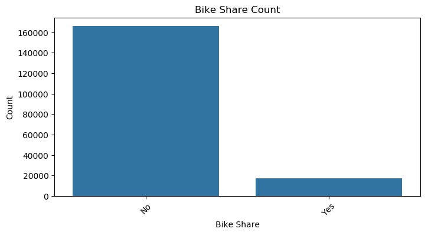

```python
plt.figure(figsize = (8,4), dpi = 100)
sb.countplot(data = data_clean, x = 'bike_share_for_all_trip', color = base_color)
plt.xlabel('Bike Share')
plt.ylabel('Count')
plt.title("Bike Share Count")
plt.xticks(rotation=45)

plt.show()
```

### Trip Distribution over the week

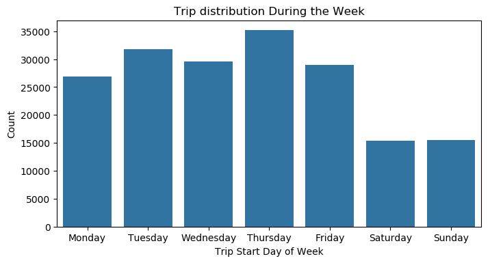

```python
plt.figure(figsize = (8,4), dpi = 100)
#define the color of the plot
base_color = sb.color_palette()[0]

#define days of the week
weekday = ['Monday', 'Tuesday', 'Wednesday', 'Thursday', 'Friday', 'Saturday', 'Sunday']
weekday_categ = pd.api.types.CategoricalDtype(ordered=True, categories=weekday)
data_clean['start_dayofweek'] = data_clean['start_dayofweek'].astype(weekday_categ)

#creating a countplot
sb.countplot(data = data_clean, x = 'start_dayofweek', color = base_color)
plt.xlabel('Trip Start Day of Week')
plt.ylabel('Count')
plt.title("Trip distribution During the Week")

plt.show()
```

### Trip Distribution By Duration in Minutes

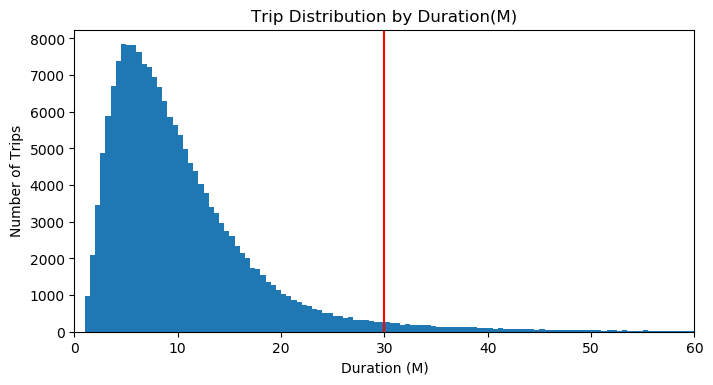

```python
plt.figure(figsize = (8,4), dpi = 100)
#define bin size
bins=np.arange(0,data_clean['duration_minute'].max()+0.5,0.5)

plt.hist(data = data_clean, x = "duration_minute",bins=bins)
plt.title("Trip Distribution by Duration(M)")
plt.xlabel('Duration (M)')
plt.ylabel('Number of Trips')
#add a vertical line across the x axis
plt.axvline(x = 30, color = "red")
plt.xlim(0, 60)
plt.show()
```

The histogram above we can see that the distribution of trips by minute duration is right skewed.

### Trip Distribution by Age

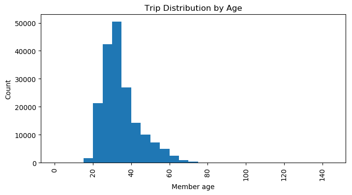

```python
plt.figure(figsize = (8,4), dpi = 100)
#defie base color for the histogram
base_color = sb.color_palette()[0]

#define bin size
bins = np.arange(0, data_clean['member_age'].max()+5, 5)
plt.hist(data = data_clean, x = 'member_age', color=base_color, bins = bins)
plt.xticks(rotation=90)
plt.xlabel('Member age')
plt.ylabel('Count')

plt.title("Trip Distribution by Age")

plt.show()
```

from the histogram distribution we can see that users aged 20-45 take up most rides. This can be attributed to the fact that this is an active population.

### Trip Distribution by Hour of Day

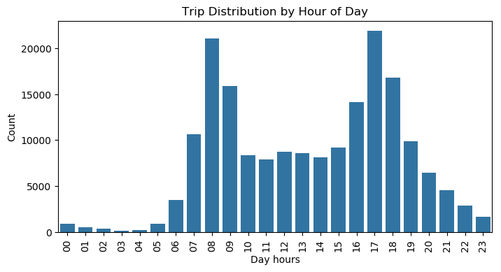

```python
plt.figure(figsize = (8,4), dpi = 100)
# define hours
hour = ['00', '01', '02', '03', '04', '05', '06', '07', '08', '09', '10', '11', '12', '13', '14', '15', '16', '17', '18', '19', '20', '21', '22', '23']
hour_categ = pd.api.types.CategoricalDtype(ordered=True, categories=hour)
data_clean['start_hourofday'] = data_clean['start_hourofday'].astype(hour_categ)


sb.countplot(data = data_clean, x = "start_hourofday", color = base_color)
plt.title("Trip Distribution by Hour of Day")
plt.xlabel('Day hours')
plt.ylabel('Count')
plt.xticks(rotation = 90)
plt.show()
```

The histogram shows that peak hours are between 7 and 9 a.m. and 4 and 6 p.m. This could be related to when employees and students arrive at and depart work and school. And the highest distribution around 5 p.m., indicating that most people found that time more convenient. Further analysis will be performed in the bivariate exploration.

### Trip Distribution By Gender

```
Male      75.739864
Female    22.268990
Other      1.991146
Name: member_gender, dtype: float64
```

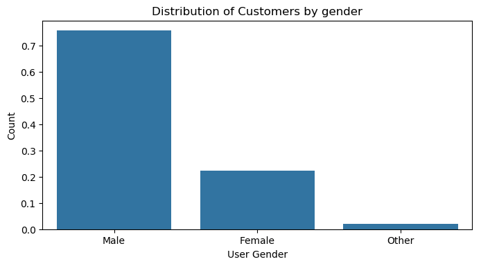

```python
plt.figure(figsize = (8,4), dpi = 100)

counts = data_clean['member_gender'].value_counts(normalize = True)
sb.barplot(x = counts.index, y = counts.values, color=base_color)
plt.xlabel('User Gender')
plt.ylabel('Count')
print(counts * 100)
plt.title("Distribution of Customers by gender")

plt.show()
```

A big percentage of users are male.

### Distribution By User Type

```
Subscriber    89.167557
Customer      10.832443
Name: user_type, dtype: float64
```

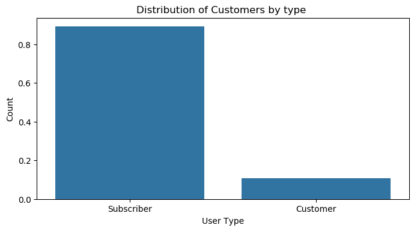

```python
plt.figure(figsize = (8,4), dpi = 100)

counts = data_clean['user_type'].value_counts(normalize = True)
sb.barplot(x = counts.index, y = counts.values, color=base_color)
plt.xlabel('User Type')
plt.ylabel('Count')
print(counts * 100)

plt.title("Distribution of Customers by type ")
plt.show()
```

```python
# ignore warnings
import warnings
warnings.simplefilter("ignore")

df1 = data_clean[data_clean["duration_minute"] <= 60]
df2 = df1[data_clean["member_age"] <= 80]

df2.head()
```

|  | duration_sec | start_time | end_time | start_station_id | start_station_name | start_station_latitude | start_station_longitude | end_station_id | end_station_name | end_station_latitude | ... | user_type | member_birth_year | member_gender | bike_share_for_all_trip | duration_minute | start_date | start_hourofday | start_dayofweek | start_month | member_age |
| --- | --- | --- | --- | --- | --- | --- | --- | --- | --- | --- | --- | --- | --- | --- | --- | --- | --- | --- | --- | --- | --- |
| 4 | 1585 | 2019-02-28 23:54:18.549 | 2019-03-01 00:20:44.0740 | 7.0 | Frank H Ogawa Plaza | 37.804562 | -122.271738 | 222.0 | 10th Ave at E 15th St | 37.792714 | ... | Subscriber | 1974.0 | Male | Yes | 26.416667 | 2019-02-28 | 23 | Thursday | February | 45.0 |
| 5 | 1793 | 2019-02-28 23:49:58.632 | 2019-03-01 00:19:51.7600 | 93.0 | 4th St at Mission Bay Blvd S | 37.770407 | -122.391198 | 323.0 | Broadway at Kearny | 37.798014 | ... | Subscriber | 1959.0 | Male | No | 29.883333 | 2019-02-28 | 23 | Thursday | February | 60.0 |
| 6 | 1147 | 2019-02-28 23:55:35.104 | 2019-03-01 00:14:42.5880 | 300.0 | Palm St at Willow St | 37.317298 | -121.884995 | 312.0 | San Jose Diridon Station | 37.329732 | ... | Subscriber | 1983.0 | Female | No | 19.116667 | 2019-02-28 | 23 | Thursday | February | 36.0 |
| 7 | 1615 | 2019-02-28 23:41:06.766 | 2019-03-01 00:08:02.7560 | 10.0 | Washington St at Kearny St | 37.795393 | -122.404770 | 127.0 | Valencia St at 21st St | 37.756708 | ... | Subscriber | 1989.0 | Male | No | 26.916667 | 2019-02-28 | 23 | Thursday | February | 30.0 |
| 8 | 1570 | 2019-02-28 23:41:48.790 | 2019-03-01 00:07:59.7150 | 10.0 | Washington St at Kearny St | 37.795393 | -122.404770 | 127.0 | Valencia St at 21st St | 37.756708 | ... | Subscriber | 1988.0 | Other | No | 26.166667 | 2019-02-28 | 23 | Thursday | February | 31.0 |

5 rows × 22 columns

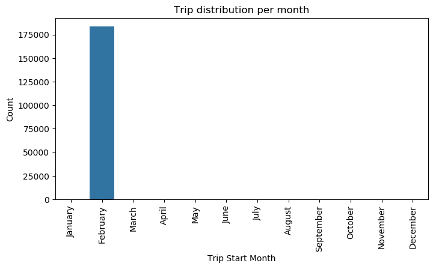

```python
plt.figure(figsize = (8,4), dpi = 100)
#define months
month = ['January', 'February', 'March', 'April', 'May', 'June', 'July', 'August', 'September', 'October', 'November', 'December']
month_categ = pd.api.types.CategoricalDtype(ordered=True, categories=month)
data_clean['start_month'] = data_clean['start_month'].astype(month_categ)

sb.countplot(data = data_clean, x='start_month', color=base_color)
plt.xticks(rotation=90)
plt.xlabel('Trip Start Month')
plt.ylabel('Count')

plt.title("Trip distribution per month")

plt.show()
```

### Discuss the distribution(s) of your variable(s) of interest. Were there any unusual points? Did you need to perform any transformations?

> Distribtution of interest were gender, days of the week, trip duration in minutes and distribution by hour of day. I had to transform the duration of trips into minutes.

### Of the features you investigated, were there any unusual distributions? Did you perform any operations on the data to tidy, adjust, or change the form of the data? If so, why did you do this?

> Distribution of trips by minute was unusual. A big portion of the distribution was 30 less than 30 minutes. I removed outliers in the data.

> I created new features from the time feature

## Bivariate Exploration

### Ride Distribution Based on User Type and Gender

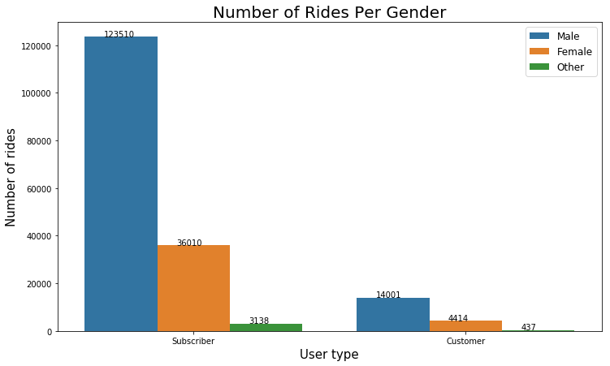

```python
plt.figure(figsize=[12,7])
ax=sb.countplot(data = df2, x ='user_type',hue='member_gender')
plt.xlabel('User type',fontsize=15)
plt.ylabel('Number of rides',fontsize=15)
plt.title('Number of Rides Per Gender',fontsize=20)
plt.legend(fontsize=12)
for p in ax.patches:
        ax.annotate('{}'.format(p.get_height()), (p.get_x()+0.07, p.get_height()+50));
```

### Trip Distribution By User Type Duration

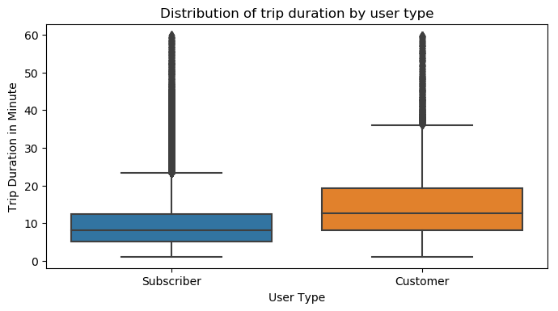

```python
plt.figure(figsize = (8,4), dpi = 100)

sb.boxplot(data = df2, x = "user_type", y = "duration_minute")
plt.xlabel('User Type');
plt.ylabel('Trip Duration in Minute')

plt.title("Distribution of trip duration by user type")

plt.show()
```

From the boxplot above, we can see that subscribers usually have short trip durations while customers often have longer duration trips.

### Trip Duration During The Days of The Week

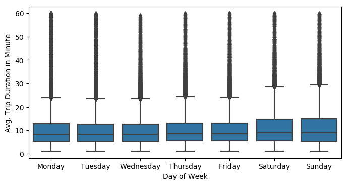

```python
plt.figure(figsize = (8,4), dpi = 100)

sb.boxplot(data = df2, x = "start_dayofweek", y = "duration_minute", color=base_color)
plt.xlabel('Day of Week');
plt.ylabel('Avg. Trip Duration in Minute')

plt.show()
```

### Trip Distribution over Hours of Day by User Type

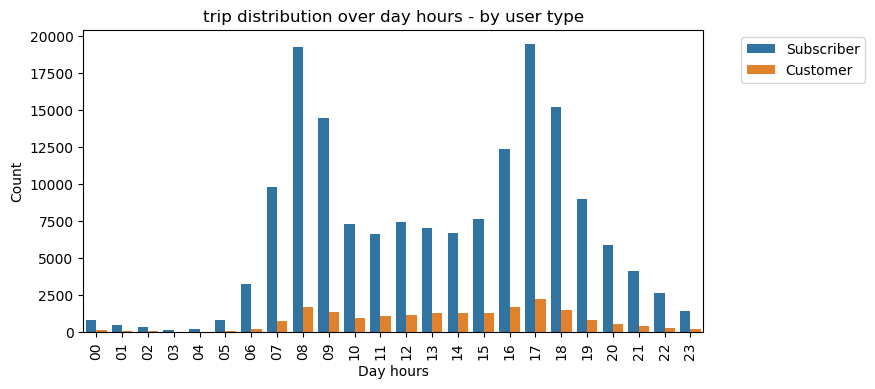

```python
plt.figure(figsize = (8,4), dpi = 100)

sb.countplot(data = df2, x = "start_hourofday", hue='user_type')
plt.title("trip distribution over day hours - by user type")
plt.xlabel('Day hours')
plt.ylabel('Count')
plt.xticks(rotation = 90)
plt.legend(bbox_to_anchor=(1.05, 1), loc='upper left')

plt.show()
```

### Age distribution by User Type

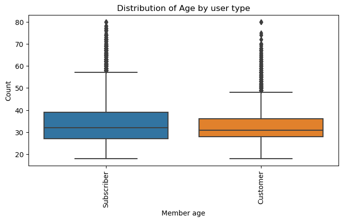

```python
plt.figure(figsize = (8,4), dpi = 100)

sb.boxplot(data=df2, x = "user_type", y='member_age')
plt.xticks(rotation=90)
plt.xlabel('Member age')
plt.ylabel('Count')

plt.title("Distribution of Age by user type")

plt.show()
```

### Talk about some of the relationships you observed in this part of the investigation. How did the feature(s) of interest vary with other features in the dataset?

> Duration of bike rides is determined by time of day and user types.

### Did you observe any interesting relationships between the other features (not the main feature(s) of interest)?

> An interesting relationship is that subscribers have more bike trips than customers between 0700 hours and 1800hours

## Multivariate Exploration

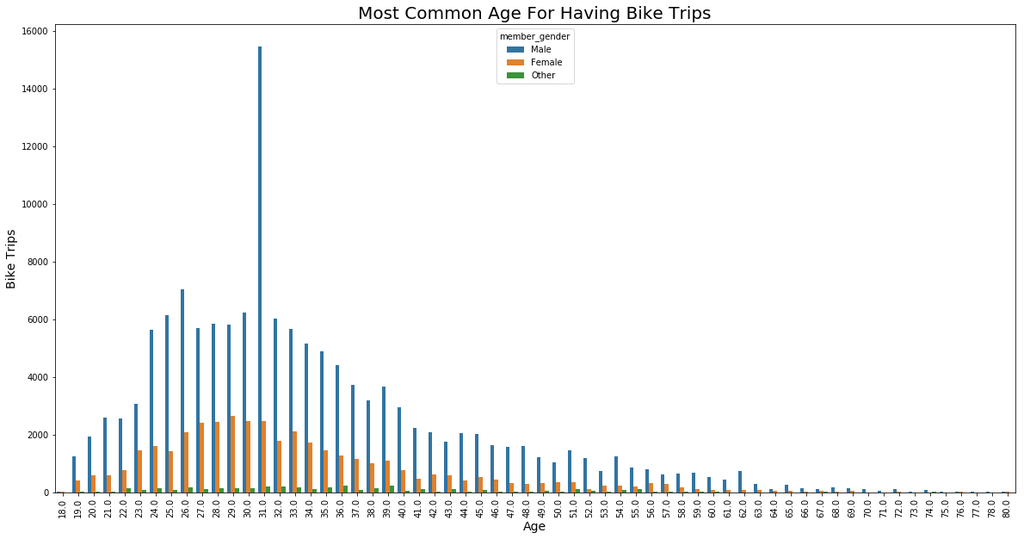

```python
fig, ax = plt.subplots(figsize=(20,10))
ax = sb.countplot(data = df2, x = df2['member_age'], hue='member_gender')
plt.title('Most Common Age For Having Bike Trips', fontsize=20)
plt.ylabel('Bike Trips', fontsize=14)
plt.xlabel('Age', fontsize=14);
plt.xticks(rotation=90);
```

The analysis for user age and gender that like having bike rides. From the count plot above, we can deduce that females between 25 and 38 like having bike rides.

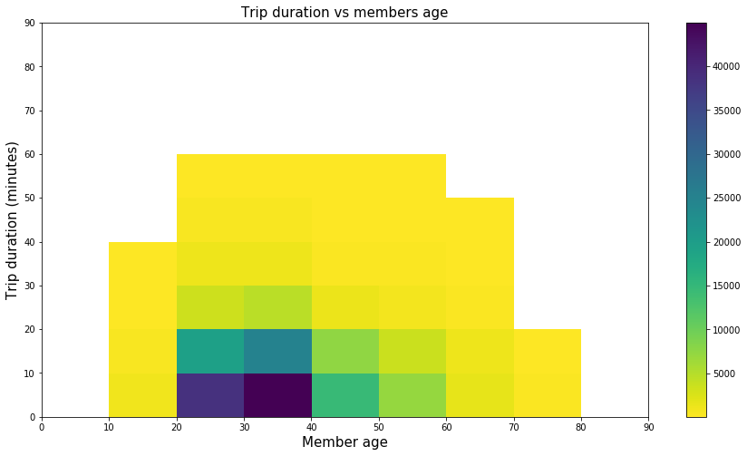

```python
#define bin size for the x axis
bin_x=np.arange(0,100,10)
#define bin size for the y axis
bin_y=np.arange(0,100,10)
plt.figure(figsize=[15,8])
plt.hist2d(data = df2, x = 'member_age',y = 'duration_minute',cmin=50,cmap='viridis_r',bins=[bin_x,bin_y])
plt.colorbar()
plt.xlabel('Member age',fontsize=15)
plt.ylabel('Trip duration (minutes)',fontsize=15)
plt.title('Trip duration vs members age',fontsize=15);
```

From the visualization above, we can see that users between the age of 20 and 40 have trips whose duration is below 20 minutes

### Talk about some of the relationships you observed in this part of the investigation. Were there features that strengthened each other in terms of looking at your feature(s) of interest?

> From this investigation it is clear that users between 20 to 40 years have the highest number of bike rides. However the duration of their trips is less than 20 minutes

### Were there any interesting or surprising interactions between features?

> From the analysis made, there is an intersetin relationshiip between age and gender of the users.